# MOFAmodel Factor2 - Gene set enrichment analysis

### Plot GSEA results

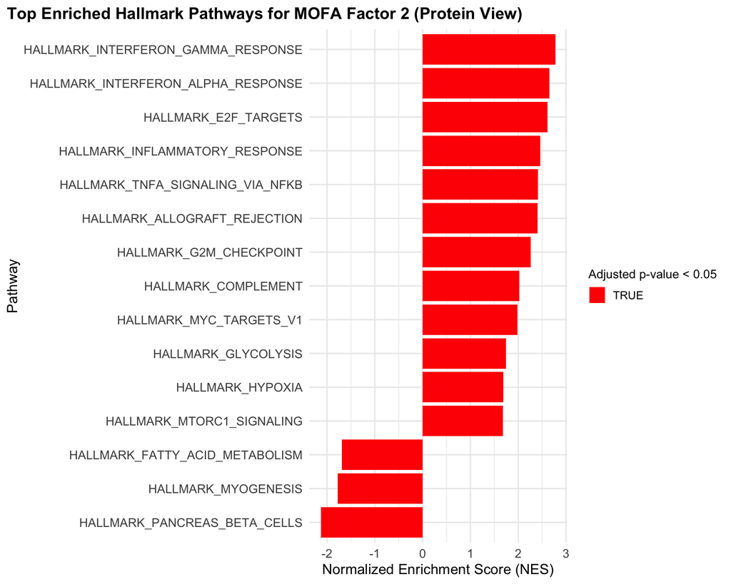

```r
# Plot the top enriched pathways
topPathways %>%
  ggplot(aes(reorder(pathway, NES), NES)) +
  geom_col(aes(fill = padj < 0.05)) +
  coord_flip() +
  labs(x = "Pathway", y = "Normalized Enrichment Score (NES)",
       title = "Top Enriched Hallmark Pathways for MOFA Factor 2 (Protein View)") +
  theme_minimal(base_size = 14) +
  theme(plot.title = element_text(size = 16, face = "bold", hjust = 0),
        plot.title.position = "plot",
        axis.title = element_text(size = 14),
        axis.text = element_text(size = 12),
        legend.title = element_text(size = 12),
        legend.text = element_text(size = 11)) +
  scale_fill_manual(name = "Adjusted p-value < 0.05", values = c("TRUE" = "red", "FALSE" = "grey"))
```

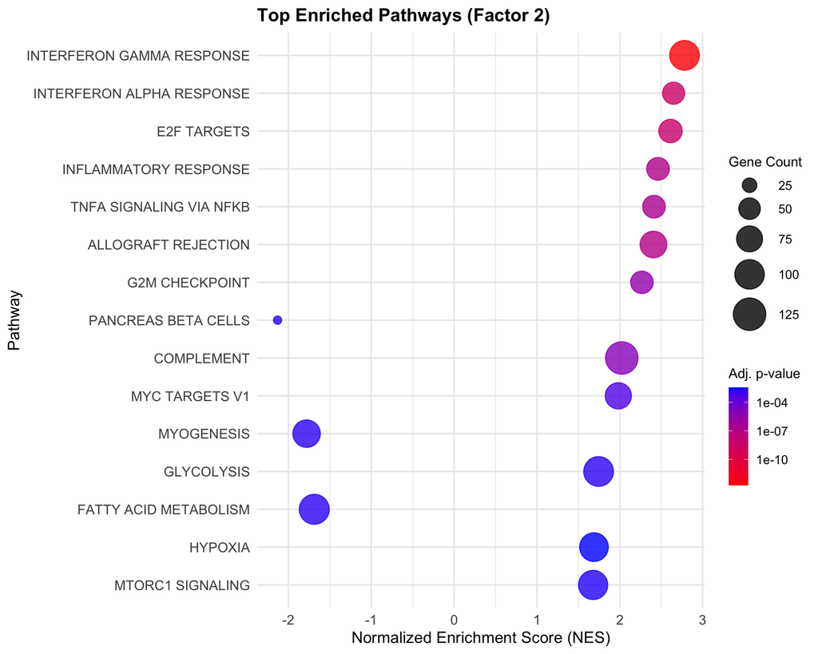

```r
# Bubble plot of top 15 pathways
## Prepare data for plotting
# plot_data <- fgseaRes %>%
#   arrange(padj) %>%
#   head(10) %>%
#   mutate(pathway = gsub("HALLMARK_", "", pathway),
#          pathway = gsub("_", " ", pathway))

plot_data <- topPathways %>%
  mutate(pathway = gsub("HALLMARK_", "", pathway),
         pathway = gsub("_", " ", pathway))

## Create bubble plot
ggplot(plot_data, aes(x = NES, y = reorder(pathway, abs(NES)), size = size, color = padj)) +
  geom_point(alpha = 0.8) +
  scale_size_continuous(range = c(3, 13)) +
  scale_color_continuous(low = "red", high = "blue", trans = "log10") +
  theme_minimal(base_size = 14) +
  theme(plot.title = element_text(size = 16, face = "bold"),
        axis.title = element_text(size = 14),
        axis.text = element_text(size = 12),
        legend.title = element_text(size = 12),
        legend.text = element_text(size = 11)) +
  labs(title = "Top Enriched Pathways (Factor 2)",
       x = "Normalized Enrichment Score (NES)",
       y = "Pathway",
       size = "Gene Count",
       color = "Adj. p-value")
```

### The “Survival Engine” of Factor 2: A Multi-Omic Synthesis

#### 2. The Basal-like “Perfect Storm”: Inflammation and Proliferation

The high-risk spectrum of Factor 2 is anchored by an intense Interferon ($\gamma$ and $\alpha$) and Inflammatory Response ($NES > 2.4$). While often associated with anti-tumor activity, chronic Interferon signaling in PDAC is a hallmark of the Basal-like/Squamous transition, driving therapy resistance and immune evasion [3, 4]. This is coupled with a rapid proliferative switch, evidenced by the enrichment of E2F Targets and G2M Checkpoint pathways ($NES > 2.2$), signaling a loss of the quiescent, differentiated state [5].

#### 3. The Mechanical-Hypoxic Axis: Stroma and Glycolysis

A major revelation in the top 15 is the inclusion of Hypoxia and Glycolysis.

- **Mechanical Stiffening:** Drivers like PLOD1/2 and COLGALT1 increase collagen cross-linking, creating a dense, desmoplastic stroma [6].
- **The Hypoxic Consequence:** This dense stroma collapses local vasculature, leading to Hypoxia ($NES = 1.68$). To survive, the tumor “switches” to Glycolysis ($NES = 1.73$) to maintain energy production under stress, a metabolic pivot strongly associated with poor prognosis [7, 8].

### References

1. Cao, L., et al. (2021). “Proteogenomic characterization of pancreatic ductal adenocarcinoma.” *Cell*.
2. Chan, D. W., et al. (2019). “The CPTAC Initiative: Mapping the Proteogenomic Landscape of Cancer.” *Cancer Research*.
3. Bailey, P., et al. (2016). “Genomic analyses identify molecular subtypes of pancreatic cancer.” *Nature*.
4. Jorgensen, C., et al. (2017). “The role of the tumor microenvironment in PDAC subtype transitions.” *JCI*.
5. Moffitt, R. A., et al. (2015). “Virtual microdissection retains clinical and molecular subtypes of pancreatic cancer.” *Nature Genetics*.
6. Tian, C., et al. (2021). “PLOD2-mediated collagen cross-linking promotes metastasis… and is a potential therapeutic target.” *Theranostics*.
7. Chen, Y., et al. (2018). “Lysyl hydroxylase 2 (PLOD2) promotes TGF-$\beta$-induced EMT and metastasis in PDAC.” *BBRC*.
8. Shukla, S. K., et al. (2017). “Metabolic reprogramming in pancreatic cancer: Glycolysis as a central player.” *Cancer Letters*.
9. Kim, J., et al. (2019). “ALDH1A1 contributes to lineage differentiation and is a marker of better prognosis in PDAC.” *Oncology Letters*.
10. Daemen, A., et al. (2015). “Pancreatic cancer cell lines provide a model for clinical subtypes and prognosis.” *Clinical Cancer Research*. (Discussing metabolic shifts in PDAC).